# Report Exercise Chapter 10

## Model with pooled data

#### Train a single model with training data pooled from both sites and predict with this single model on the test data of both sites

With the pooling of the Laegern and Davos datasets, there also needs to be a new training model (with caret::train) mod_pool. The procedure is the same as for the previous datasets.

```r
# pool data
#before being able to pool the data, I need to drop the columns that don't appear in both as otherwise I cannot combine the dataframes
daily_fluxes_Dav_train <- daily_fluxes_Dav_train[!(colnames(daily_fluxes_Dav_train)) == "P_F"]

daily_fluxes_Lae_train <- daily_fluxes_Lae_train[!(colnames(daily_fluxes_Lae_train)) == "LW_IN_F"]



daily_fluxes_train_pool <- rbind(daily_fluxes_Dav_train, daily_fluxes_Lae_train)


pp_pool <- recipes::recipe(GPP_NT_VUT_REF ~ SW_IN_F + VPD_F + TA_F,
                      data = daily_fluxes_train_pool) |>
  recipes::step_center(all_numeric(), -all_outcomes()) |>
  recipes::step_scale(all_numeric(), -all_outcomes())

mod_pool <- caret::train(pp_pool,
                    data = daily_fluxes_train_pool |> drop_na(),
                    method = "knn",
                    trControl = caret::trainControl(method = "cv",
                                                    number = 60
                                                    ),
                    tuneGrid = data.frame(k = c(2, 5, 10, 15, 20, 25, 30, 35, 40, 60, 100)),
                    metric = "MAE"
                    )

mod_pool
```

```
## k-Nearest Neighbors
##
## 7263 samples
##    6 predictor
##
## Recipe steps: center, scale
## Resampling: Cross-Validated (60 fold)
## Summary of sample sizes: 7143, 7143, 7141, 7141, 7141, 7142, ...
## Resampling results across tuning parameters:
##
##   k    RMSE      Rsquared   MAE
##     2  2.392463  0.5507565  1.769614
##     5  2.160244  0.6153461  1.589416
##    10  2.071651  0.6425921  1.527298
##    15  2.042944  0.6515377  1.510209
##    20  2.032224  0.6549370  1.503130
##    25  2.020551  0.6588019  1.496827
##    30  2.015671  0.6604893  1.493279
##    35  2.016716  0.6602466  1.491673
##    40  2.013493  0.6613781  1.490280
##    60  2.015941  0.6609132  1.494415
##   100  2.026371  0.6581021  1.506501
##
## MAE was used to select the optimal model using the smallest value.
## The final value used for the model was k = 40.
```

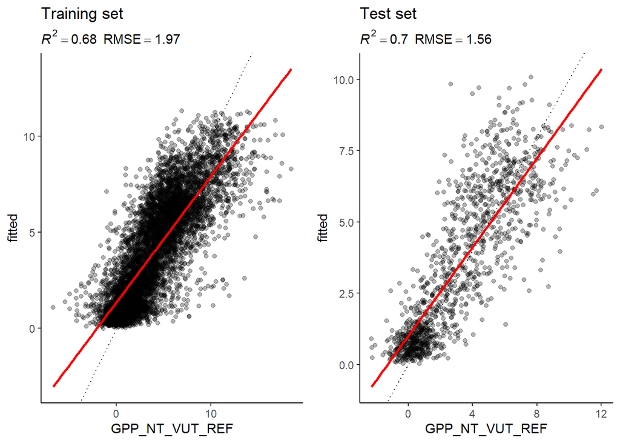

*Figure 5: Evaluation of GPP knn model fit vs. GPP measurements using pooled data to predict the Davos test data*

```r
eval_model(mod = mod_pool, df_train = daily_fluxes_train_pool, df_test = daily_fluxes_Dav_test)
```

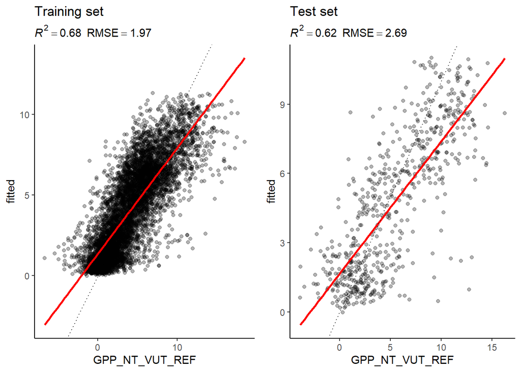

```r
eval_model(mod = mod_pool, df_train = daily_fluxes_train_pool, df_test = daily_fluxes_Lae_test)
```

## Comparing the the two sites

#### Get information about the characteristics of the two sites. What are the differences in terms of climate, vegetation, altitude, etc. between the Davos and Laegern sites? Interpret biases of the out-of-sample predictions with a view to the site characteristics.

Davos: 1639 m above sea level Laegern: 689 m above sea level

Davos is in the alps, Laegern in the Swiss pleateau

Vegetation: Davos: Evergreen Needleleaf Forest, meaning most trees remain green even in Winter Laegern: Mixed Forest without any overly dominant forest type

Annual Temp: Davos: 2.8°C Laegern: 8.3°C

Annual Precipitation: Davos: 1062 mm Laegern: 1100 mm

To compare the out.of-sample predictions of the two sites, we once again turn to temporal variations of fits vs. GPP measurements. To both sites measurements we compare the within-site and across-site predictions, and hope to find some consistent differences in the predictions that could be explained by the differences in the site characteristics.

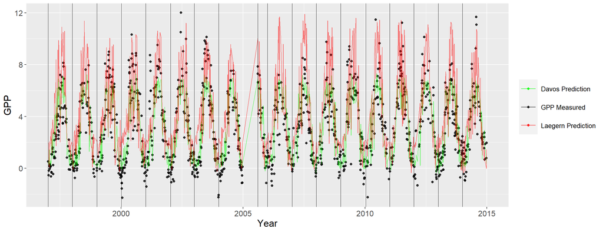

*Figure 5: Time variation for the site of Davos of measured GPP and precictions using both sites training data*

```r
colors1 <- c("GPP Measured" = "black", "Davos Prediction" = "green", "Laegern Prediction" = "red")

yearstart <- daily_fluxes_Dav_test[match(unique(year(daily_fluxes_Dav_test$TIMESTAMP)), year(daily_fluxes_Dav_test$TIMESTAMP)),][,1]

yearstart$TIMESTAMP <- as.numeric(yearstart$TIMESTAMP)
#select the first date with an obs of every year and then put a line there on the plots as to make it easier to read when the year starts and thus easier to see the results



ggplot() +
  geom_point(data = daily_fluxes_Dav_test, aes(x = TIMESTAMP, y = GPP_NT_VUT_REF,  color = "GPP Measured"), alpha = 0.8) +
  geom_line(data = daily_fluxes_Dav_test, aes(x = TIMESTAMP, y = Dav_fitted,  color = "Davos Prediction"), alpha = 0.5) +
  geom_line(data = daily_fluxes_Dav_test, aes(x = TIMESTAMP, y = Lae_fitted,  color = "Laegern Prediction"), alpha = 0.5) +

    scale_color_manual(values = colors1) +
  geom_vline(xintercept = yearstart$TIMESTAMP, color = "black", linewidth = 0.3) +

  labs(x = "Year", y = "GPP") +

  theme(axis.text = element_text(size = 12), axis.title = element_text(size = 15)) +

  theme(legend.key.size = unit(1, "cm"),
    legend.text = element_text(size = 10), legend.title = element_blank())
```

```r
#note: the start of year look really weird in the middle due to there only being very little data for 2005
```

In this first graphic about the measured GPP vs. predictions for the Davos test set we can see a few things: 1) The across-site predictions using the Laegern training data overestimate the GPP by quite a big margin in summer. 2) In winter/early spring, the predictions using Laegern training data seem to consistently “go back up” from the winterly low a few weeks earlier than the actual data and Davos predictions.

These diffrences could, in part, be due to the differences in vegetation, as with similar Temperature, Radiation etc. mixed forest with more deciduous trees may have a greater GPP than full evergreen needleleaf forests.

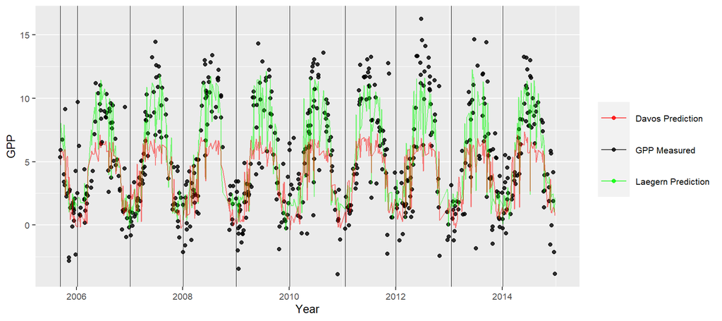

```r
colors1 <- c("GPP Measured" = "black", "Laegern Prediction" = "green", "Davos Prediction" = "red")

yearstart2 <- daily_fluxes_Lae_test[match(unique(year(daily_fluxes_Lae_test$TIMESTAMP)), year(daily_fluxes_Lae_test$TIMESTAMP)),][,1]


yearstart2$TIMESTAMP <- as.numeric(yearstart2$TIMESTAMP)



ggplot() +
  geom_point(data = daily_fluxes_Lae_test, aes(x = TIMESTAMP, y = GPP_NT_VUT_REF,  color = "GPP Measured"), alpha = 0.8) +
  geom_line(data = daily_fluxes_Lae_test, aes(x = TIMESTAMP, y = Lae_fitted,  color = "Laegern Prediction"), alpha = 0.5) +
  geom_line(data = daily_fluxes_Lae_test, aes(x = TIMESTAMP, y = Dav_fitted,  color = "Davos Prediction"), alpha = 0.5) +

    scale_color_manual(values = colors1) +
  geom_vline(xintercept = yearstart2$TIMESTAMP, color = "black", linewidth = 0.3) +

  labs(x = "Year", y = "GPP") +

  theme(axis.text = element_text(size = 8), axis.title = element_text(size = 10)) +

  theme(legend.key.size = unit(1, "cm"),
    legend.text = element_text(size = 8), legend.title = element_blank())
```

When looking at the predictions onto the Laegern dataset, we can come to the same conclusions: the Laegern predictions (as well as the measurements) go way above the predictions using Davos training data in summer, indicating that the gross primary production is higher in Laegern than in Davos in summer even when every external factor is kept even. Without further research, it is hard to make any clear call whether or not this is due to the forest type or if other factors play more of a role in shaping these differences.